# Data preparation and running synapsis

Lucy McNeill

30/06/2021

# Preparing your data

In this notebook we will give a comprehensive guide for preparing image data so that it is compatible with synapsis.

Since synapsis relies on EBImage, target files must also be .jpeg, .tiff, or .png.

Synapsis also requires that a single microscope image has been converted into independent channels, i.e. there are two or three images corresponding to the same original image.

But microscopes output many different file formats e.g. .lif, .nd2 etc.

If your dataset is a series of .jpegs, .pngs, or .tiffs (which haven’t been split into channels yet), use *section A*

If your dataset is a series of .nd2 files, use *section B.*

If your data set is already a series of double or triple .jpegs, .pngs, or .tiffs corresponding to the same image, labelled by the two or three antibodies/ stains, you are ready to use synapsis on your data.

## File naming convention

Before we get started, we should establish a filenaming convention. Each original image consists of two or three channels of interest. These correspond to particular antibodies/ stains. The idea is that this original “stacked” image has a file name “base”.

For example, the file :

```r
MLH3mouse488_SYCP3mouse647_fancm_fvb_x_fancm_bl6_exon2_875--_VT_002.nd2
```

has a filename base

```r
MLH3mouse488_SYCP3mouse647_fancm_fvb_x_fancm_bl6_exon2_875--_VT_002
```

We isolate the individual channels, and rename them with the antibody or stain appended to the file name base. For example, if the three channels are DAPI, MLH3 and SYCP3, then we create three images from this file called

```r
MLH3mouse488_SYCP3mouse647_fancm_fvb_x_fancm_bl6_exon2_875--_VT_002-DAPI.tiff
MLH3mouse488_SYCP3mouse647_fancm_fvb_x_fancm_bl6_exon2_875--_VT_002-SYCP3.tiff
MLH3mouse488_SYCP3mouse647_fancm_fvb_x_fancm_bl6_exon2_875--_VT_002-MLH3.tiff
```

Synapsis has particular purposes for families of stains/ antibodies (i.e. foci channel, chromosome channel etc), so users have to be aware of which channel is which and make sure channels are named accordingly.

## Section A: splitting a folder full of .jpeg, .png or .tiff files using EBImage

The three colour .jpeg files have SYCP3 as red, MLH3 as green and DAPI as blue.

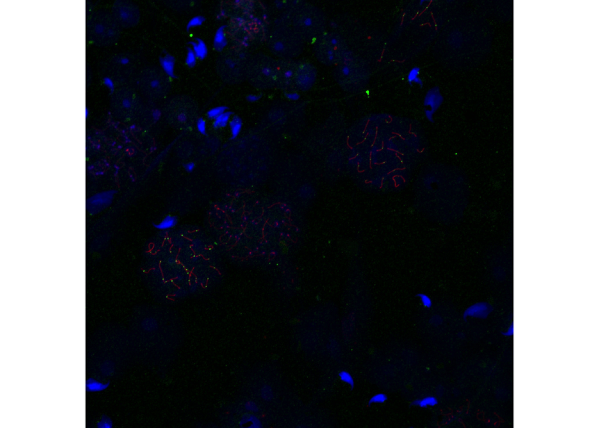

```r
library(EBImage)
path = paste0(system.file("extdata",package = "synapsis"))
file_3channel <- paste0(path,"/MLH3rabbit488_SYCP3mouse594_fancm_fvb_x_fancm_bl6_724++_slide01_006-RGB.jpeg")
image_3channel <- readImage(file_3channel)
display(image_3channel)
```

Now we can convert these into their respective channels, keeping in mind our naming convention and which colours correspond to particular stains and antibodies.

```r
r = channel(image_3channel,"r")
g = channel(image_3channel,"g")
b = channel(image_3channel,"b")
```

To do this for a whole folder, where in this example all images end in “-RGB.jpeg”, use this loop instead:

```r
library(EBImage)
# location of the jpeg/png/tiff files to convert into three channel jpeg/png/tiff
path = 'data-folder/from-sharepoint/OneDrive_1_01-06-2021'
file_list <- list.files(path)
print(file_list)
for (file in file_list){
  if(grepl(paste0('*RGB.jpeg$'), file)){
    file_stub <- '-RGB.jpeg'
    file_base <- gsub(file_stub,'', file)
    print(file_base)
    image_3channel <- readImage(paste0(path,'/',file))
    r = channel(image_3channel,"r")
    writeImage(r, paste0(paste0(path,'/',file_base,'-SYCP3.tiff')))
    g = channel(image_3channel,"g")
    writeImage(g, paste0(paste0(path,'/',file_base,'-MLH3.tiff')))
    b = channel(image_3channel,"b")
    writeImage(b, paste0(paste0(path,'/',file_base,'-DAPI.tiff')))
  }

}
```

Where you can freely convert between jpeg, tiff, png conversions as you wish.

## Section B: splitting a folder full of .nd2 files into three channels using python

These .nd2 files used in examples have DAPI as the first layer, MLH3 as the second and SYCP3 as the third layer. If for some reason your layers are in a different order, and or correspond to different antibodies, make sure you modify this in the python script (around lines 40, 59, 78)

Run the following in a python script e.g. in a jupyter notebook:

Make sure you change your parent_dir to where your original .nd2 files are stored.

```r
from nd2reader import ND2Reader
import matplotlib.pyplot as plt
import numpy as np
import os
import glob
from PIL import Image

# location of the nd2 files to convert into three channel jpeg/png/tiff
parent_dir = 'data-folder/from-sharepoint/OneDrive_1_01-06-2021'
filenames = []
filenames_base = []

for file in glob.glob(os.path.join(parent_dir, '*nd2')):
    filenames.append(file)

filenames = sorted(filenames)

for name in filenames:
    base=os.path.basename(name)
    os.path.splitext(base)
    name_base = os.path.splitext(base)[0]
    new_name = parent_dir+'/'+str(name_base)
    print(new_name)

    try:

        with ND2Reader(str(name)) as images:
            plt.figure(figsize = (10,10))
            plt.gca().set_axis_off()
            plt.subplots_adjust(top = 1, bottom = 0, right = 1, left = 0,
                    hspace = 0, wspace = 0)
            plt.margins(0,0)
            plt.gca().xaxis.set_major_locator(plt.NullLocator())
            plt.gca().yaxis.set_major_locator(plt.NullLocator())
            plt.imshow(images[0],cmap = 'gray')
        ### keep metadata... e.g.
        ## savefig(fname, dpi=None, facecolor='w', edgecolor='w',
        ## orientation='portrait', papertype=None, format=None,
        ## transparent=False, bbox_inches=None, pad_inches=0.1,
        ## frameon=None, metadata=None)
            plt.savefig(str(new_name)+'-DAPI.jpeg')
            plt.figure(figsize = (10,10))
            plt.gca().set_axis_off()
            plt.subplots_adjust(top = 1, bottom = 0, right = 1, left = 0,
                hspace = 0, wspace = 0)
            plt.margins(0,0)
            plt.gca().xaxis.set_major_locator(plt.NullLocator())
            plt.gca().yaxis.set_major_locator(plt.NullLocator())
            plt.imshow(images[1],cmap = 'gray')
            plt.savefig(str(new_name)+'-MLH3.jpeg')
            plt.figure(figsize = (10,10))
            plt.gca().set_axis_off()
            plt.subplots_adjust(top = 1, bottom = 0, right = 1, left = 0,
                    hspace = 0, wspace = 0)
            plt.margins(0,0)
            plt.gca().xaxis.set_major_locator(plt.NullLocator())
            plt.gca().yaxis.set_major_locator(plt.NullLocator())
            plt.imshow(images[2],cmap = 'gray')
            plt.savefig(str(new_name)+'-SYCP3.jpeg')

    except:
        print("Couldn't open file"+str(name))
```